[figure not shown]

# Rochester Region Federal Funds Dashboard

#### How the Rochester Region Is Spending Federal Recovery Dollars

66%

Percent of SLFRF funds allocated toward an inclusive recovery and equitable economy in the **City of Rochester and Monroe County Combined**

54%

Percent of SLFRF funds allocated toward an inclusive recovery and equitable economy in the **City of Rochester**

89%

Percent of SLFRF funds allocated toward an inclusive recovery and equitable economy in **Monroe County**

This dashboard tracks data on how the City of Rochester and Monroe County have allocated State and Local Fiscal Recovery Funds (SLFRF) provided through the [American Rescue Plan Act (ARPA)](https://www.whitehouse.gov/american-rescue-plan/). The federal government has transferred unprecedented levels of flexible relief funds to local governments to help them recover from the economic impacts of the COVID-19 pandemic and to move into longer-term growth. These funds grant a great deal of authority to municipal governments to decide how they should be spent, and they must be obligated by the end of 2024 and spent by the end of 2026. As the City of Rochester and Monroe County [allocate and spend](https://www.urban.org/sites/default/files/publication/105119/harnessing-federal-funds-for-inclusive-recovery-in-rochester-ny_0.pdf) these funds, they have [an opportunity](https://www.urban.org/research/publication/how-equity-helps-lift-all-boats) to not only stimulate economic growth, but to increase equity and remediate some of the past injustices that have been [built into our nation’s laws and programs](https://books.google.com/books?hl=en&lr=&id=SdtDDQAAQBAJ&oi=fnd&pg=PT4&dq=color+of+law&ots=RL_u4QqRBH&sig=eYYnHvwibwB_XBfpzr0jQVK2SOs#v=onepage&q=color%20of%20law&f=false). To do so, the funds [must be used](https://www.urban.org/research/publication/inclusive-recovery-us-cities) to ensure that everyone–especially historically excluded groups–can benefit from and contribute to economic growth.

[Previous work by the Urban Institute](https://www.urban.org/sites/default/files/publication/105290/aligning-the-use-of-recovery-funds-with-community-goals-in-rochester-new-york.pdf) identified five building blocks of an inclusive recovery and equitable economy, shown below. These were identified based on empirical research and in collaboration with community leaders from across the country. We focus on how well Rochester and Monroe County’s SLFRF allocations align with the building blocks of an inclusive recovery and equitable economy.

**The Building Blocks of An Inclusive Recovery and Equitable Economy**

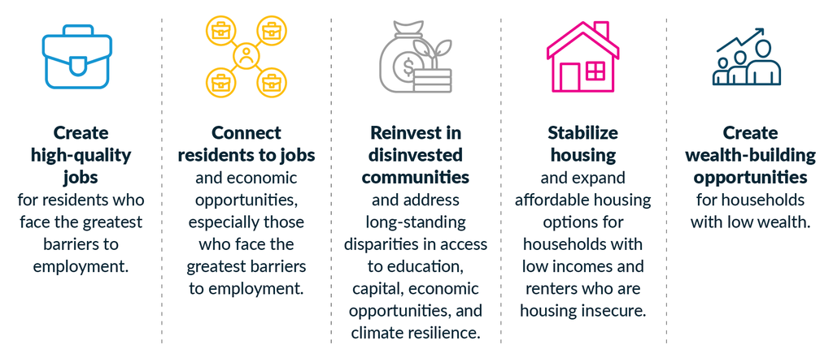

Source: Adapted from [Poethig et al 2018](https://www.urban.org/research/publication/inclusive-recovery-us-cities) in collaboration with community stakeholders across the country

**The dashboard is laid out as follows:**

- Which policy areas are being funded?
- How much is allocated toward an inclusive recovery and equitable economy?
- How does funding align with Rochester Area Community Foundation’s priorities?
- Which neighborhoods are the funds allocated to?
- Detailed table of all allocations and their descriptions

**Note: This dashboard does not track outcomes from these investments – it only shows where the dollars are flowing**[^1].

## Which policy areas are being funded?

The figure below shows how funding has been allocated across policy categories. Most of the funds have been allocated to community and economic development, infrastructure, and housing, while the least have been allocated to public health and COVID-19 response, operations, and public safety.

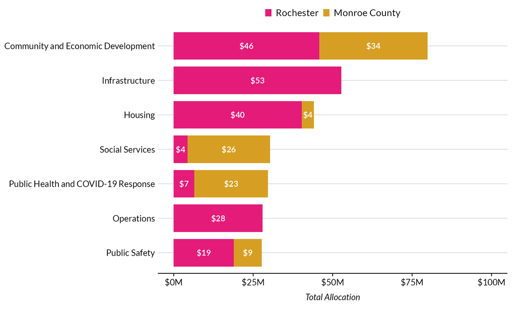

Source: Urban Institute calculations of data from [City of Rochester ARPA Reporting Dashboard](https://app.powerbi.com/view?r=eyJrIjoiNTg3NGZjNTYtYWI3NC00NTc3LWI1YTktZWJmMzY2NjBjNTBiIiwidCI6ImJlMjdkYTJlLTk0YjQtNDFkYS05NDdkLWY2MDJkNjBlODA3YyJ9) and [Monroe County Recovery Plan 2023 Annual Report](https://www.monroecounty.gov/files/planning/arpa/July_2023_ARPA_Report_V3_8-22-23_With_Attachments.pdf)

### Which subtopics are funded within each policy area?

The figure below provides a more detailed breakdown of subtopic allocations within each policy area. For example, most of the money allocated to community and economic development has been allocated to workforce development. Click on each tab to see allocations toward subtopics within each policy area.

**Community and Economic Development**

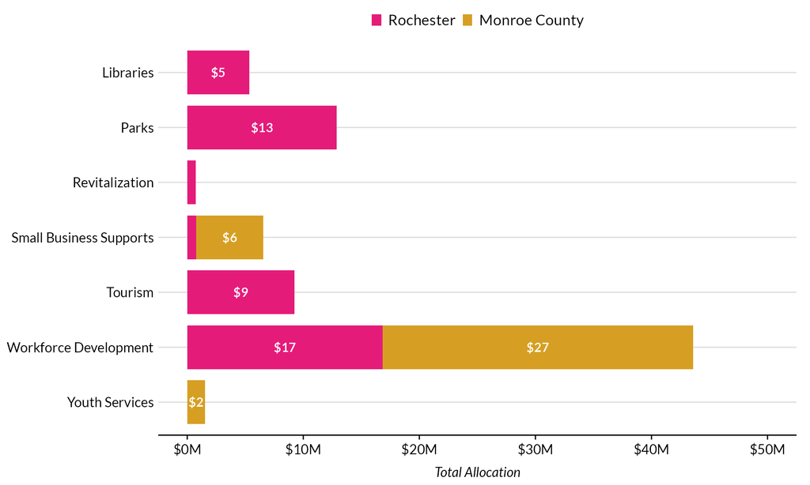

Source: Urban Institute calculations of data from [City of Rochester ARPA Reporting Dashboard](https://app.powerbi.com/view?r=eyJrIjoiNTg3NGZjNTYtYWI3NC00NTc3LWI1YTktZWJmMzY2NjBjNTBiIiwidCI6ImJlMjdkYTJlLTk0YjQtNDFkYS05NDdkLWY2MDJkNjBlODA3YyJ9) and [Monroe County Recovery Plan 2023 Annual Report](https://www.monroecounty.gov/files/planning/arpa/July_2023_ARPA_Report_V3_8-22-23_With_Attachments.pdf)

**Housing**

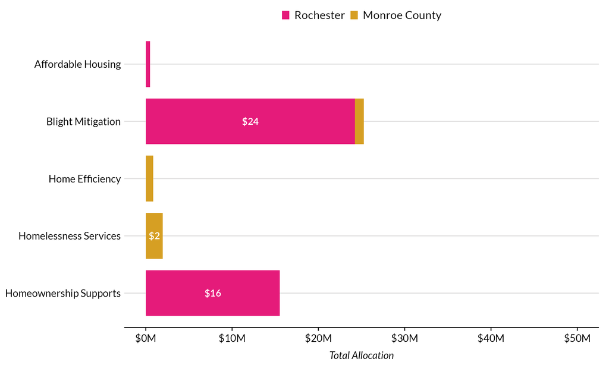

Source: Urban Institute calculations of data from [City of Rochester ARPA Reporting Dashboard](https://app.powerbi.com/view?r=eyJrIjoiNTg3NGZjNTYtYWI3NC00NTc3LWI1YTktZWJmMzY2NjBjNTBiIiwidCI6ImJlMjdkYTJlLTk0YjQtNDFkYS05NDdkLWY2MDJkNjBlODA3YyJ9) and [Monroe County Recovery Plan 2023 Annual Report](https://www.monroecounty.gov/files/planning/arpa/July_2023_ARPA_Report_V3_8-22-23_With_Attachments.pdf)

**Infrastructure**

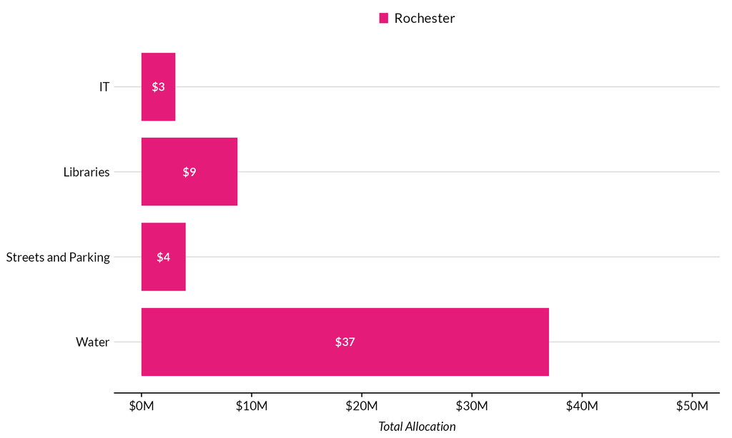

Source: Urban Institute calculations of data from [City of Rochester ARPA Reporting Dashboard](https://app.powerbi.com/view?r=eyJrIjoiNTg3NGZjNTYtYWI3NC00NTc3LWI1YTktZWJmMzY2NjBjNTBiIiwidCI6ImJlMjdkYTJlLTk0YjQtNDFkYS05NDdkLWY2MDJkNjBlODA3YyJ9) and [Monroe County Recovery Plan 2023 Annual Report](https://www.monroecounty.gov/files/planning/arpa/July_2023_ARPA_Report_V3_8-22-23_With_Attachments.pdf)

**Operations**

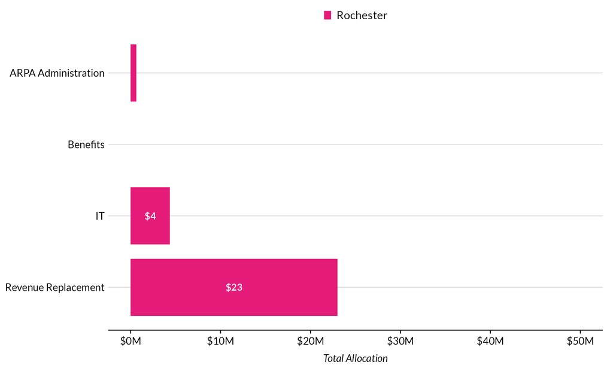

Source: Urban Institute calculations of data from [City of Rochester ARPA Reporting Dashboard](https://app.powerbi.com/view?r=eyJrIjoiNTg3NGZjNTYtYWI3NC00NTc3LWI1YTktZWJmMzY2NjBjNTBiIiwidCI6ImJlMjdkYTJlLTk0YjQtNDFkYS05NDdkLWY2MDJkNjBlODA3YyJ9) and [Monroe County Recovery Plan 2023 Annual Report](https://www.monroecounty.gov/files/planning/arpa/July_2023_ARPA_Report_V3_8-22-23_With_Attachments.pdf)

**Public Health**

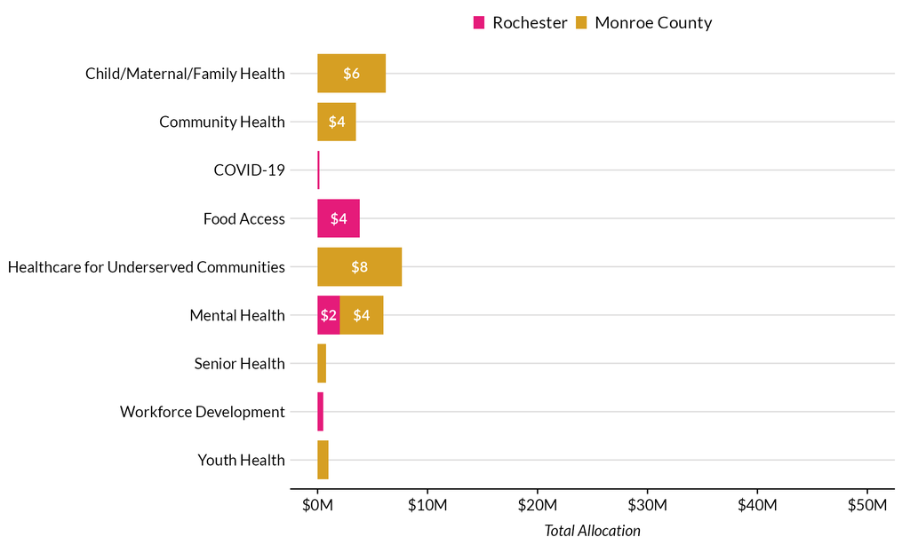

Source: Urban Institute calculations of data from [City of Rochester ARPA Reporting Dashboard](https://app.powerbi.com/view?r=eyJrIjoiNTg3NGZjNTYtYWI3NC00NTc3LWI1YTktZWJmMzY2NjBjNTBiIiwidCI6ImJlMjdkYTJlLTk0YjQtNDFkYS05NDdkLWY2MDJkNjBlODA3YyJ9) and [Monroe County Recovery Plan 2023 Annual Report](https://www.monroecounty.gov/files/planning/arpa/July_2023_ARPA_Report_V3_8-22-23_With_Attachments.pdf)

**Public Safety**

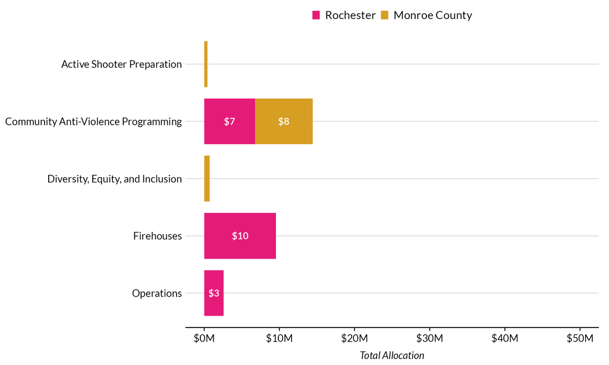

Source: Urban Institute calculations of data from [City of Rochester ARPA Reporting Dashboard](https://app.powerbi.com/view?r=eyJrIjoiNTg3NGZjNTYtYWI3NC00NTc3LWI1YTktZWJmMzY2NjBjNTBiIiwidCI6ImJlMjdkYTJlLTk0YjQtNDFkYS05NDdkLWY2MDJkNjBlODA3YyJ9) and [Monroe County Recovery Plan 2023 Annual Report](https://www.monroecounty.gov/files/planning/arpa/July_2023_ARPA_Report_V3_8-22-23_With_Attachments.pdf)

**Social Services**

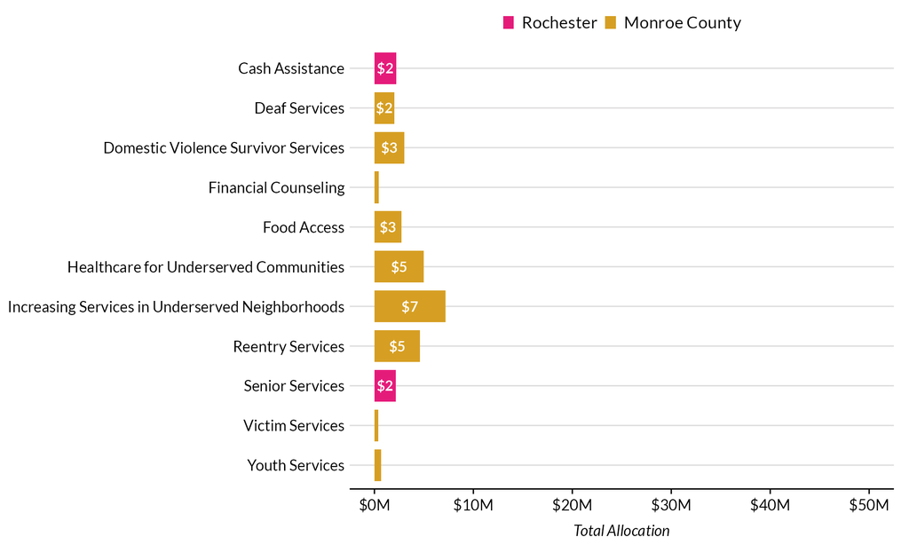

Source: Urban Institute calculations of data from [City of Rochester ARPA Reporting Dashboard](https://app.powerbi.com/view?r=eyJrIjoiNTg3NGZjNTYtYWI3NC00NTc3LWI1YTktZWJmMzY2NjBjNTBiIiwidCI6ImJlMjdkYTJlLTk0YjQtNDFkYS05NDdkLWY2MDJkNjBlODA3YyJ9) and [Monroe County Recovery Plan 2023 Annual Report](https://www.monroecounty.gov/files/planning/arpa/July_2023_ARPA_Report_V3_8-22-23_With_Attachments.pdf)

*How are federal funds supporting Rochester community members?*

These investments are making a difference in people’s lives. For example, Gabrielle Smith, seen in the video below, received funding through the City of Rochester’s Guaranteed Basic Income pilot which fits into the social services policy area under cash assistance. Through this program, she received $500 each month over 12 months, which helped her work toward her goals of buying a car and spending more time with her family. Rochester’s SLFRF funds also support [Buy the Block](https://www.cityofrochester.gov/BuyTheBlock/), a program that builds new single-family homes in under-invested areas of the city, which are then sold to qualified first-time homebuyers. The program allowed Mianel Martinez to become the first in her family to own a home for her and her daughter. Watch the short film below to hear their stories.

[video not shown]

## How much is allocated toward an inclusive recovery and equitable economy?

Based on review of the program description and goals, **66%** of city and county SLFRF funding has been allocated toward the building blocks of an inclusive recovery and equitable economy. The figure below shows the total amount of funding for Rochester and Monroe County that was allocated to programs that align with these building blocks.

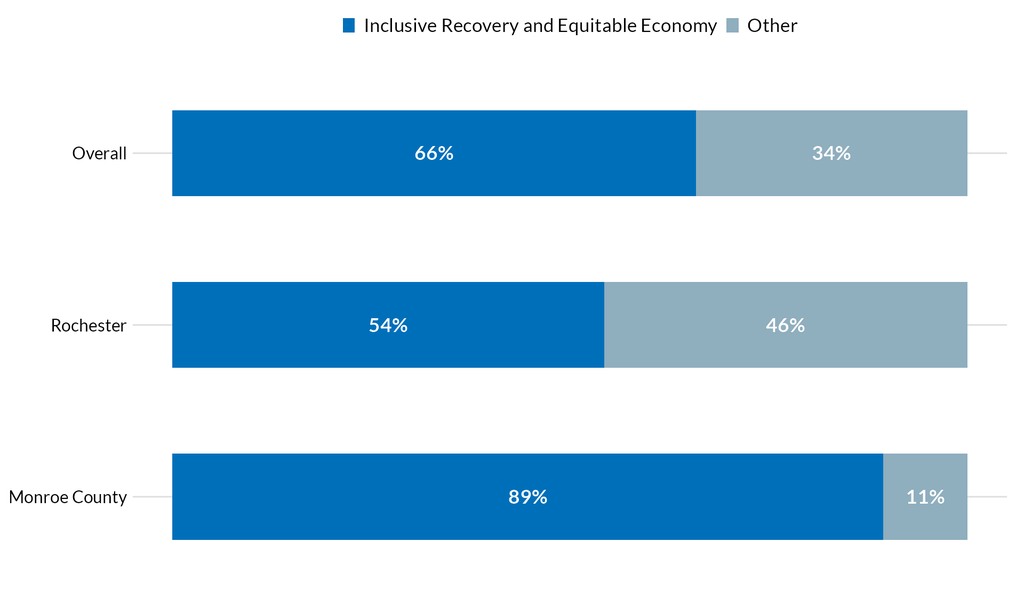

Source: Urban Institute calculations of data from [City of Rochester ARPA Reporting Dashboard](https://app.powerbi.com/view?r=eyJrIjoiNTg3NGZjNTYtYWI3NC00NTc3LWI1YTktZWJmMzY2NjBjNTBiIiwidCI6ImJlMjdkYTJlLTk0YjQtNDFkYS05NDdkLWY2MDJkNjBlODA3YyJ9) and [Monroe County Recovery Plan 2023 Annual Report](https://www.monroecounty.gov/files/planning/arpa/July_2023_ARPA_Report_V3_8-22-23_With_Attachments.pdf)

Out of the **66%** of funds allocated to programs that align with the five building blocks of an inclusive recovery and equitable economy, the most funding has been allocated to reinvesting in disinvested communities while the least has been allocated to creating jobs for residents hardest hit by the pandemic or who face the greatest barriers to employment. The figure below shows how that funding is divided among the five building blocks and includes only the funds allocated to programs that align with the building blocks (the **66%**).

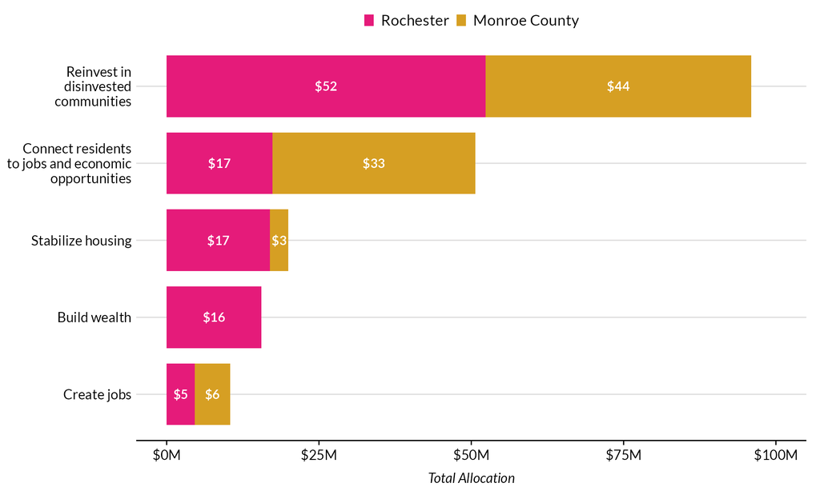

Source: Urban Institute calculations of data from [City of Rochester ARPA Reporting Dashboard](https://app.powerbi.com/view?r=eyJrIjoiNTg3NGZjNTYtYWI3NC00NTc3LWI1YTktZWJmMzY2NjBjNTBiIiwidCI6ImJlMjdkYTJlLTk0YjQtNDFkYS05NDdkLWY2MDJkNjBlODA3YyJ9) and [Monroe County Recovery Plan 2023 Annual Report](https://www.monroecounty.gov/files/planning/arpa/July_2023_ARPA_Report_V3_8-22-23_With_Attachments.pdf)

*How are other places spending recovery dollars to increase equity?*

[Dayton, Ohio](https://dayton-recovery-plan-daytonohio.hub.arcgis.com/apps/621c96849dae4536be9f84c4b1348d0d/explore) used a comprehensive community engagement process, including an online survey and series of public meetings, to inform its focus areas for ARPA spending. One of the areas identified was supporting Black- and Brown-owned businesses. This is one strategy that can [contribute to building wealth](https://www.aspeninstitute.org/publications/bridging-divide-business-ownership-can-help-close-racial-wealth-gap/) for people of color and help to close the racial wealth gap. To begin, the city undertook a comprehensive [review](https://www.daytonohio.gov/DocumentCenter/View/12678/RFP-22-020CMO-Supplement-A?bidId=) of the local business ecosystem to identify gaps in support. Based on this analysis, they created an [Inclusive Business Recovery Opportunity Center](https://www.youtube.com/watch?v=ivA56_BUI5A) to support the development, growth, and expansion of local businesses through coordination of services and capacity building. The city is also supporting Black- and Brown-owned businesses through a Micro-Grant Fund, a Racial Equity Fund, and Small Business Assistance. The city has [allocated $7.7 million to these projects](https://dayton-recovery-plan-daytonohio.hub.arcgis.com/apps/621c96849dae4536be9f84c4b1348d0d/explore).

One business [supported by this funding](https://dayton-recovery-plan-daytonohio.hub.arcgis.com/pages/dayton-recovery-plan-project-highlights#sbb) is [6888 Kitchen Incubator](https://www.6888kitchen.org/) (pronounced 6 triple 8), a commercial kitchen aiming to cultivate and support food entrepreneurs through business curriculum development, advanced mentoring, facilitation of business support, and a certified kitchen space for food preparation. Dayton’s ARPA funding supported 6888 Kitchen in capital equipment purchases to create the commercial kitchen space. The incubator [opened](https://www.daytondailynews.com/local/6888-kitchen-incubator-opens-first-phase-in-the-dayton-arcade-with-eight-small-businesses/TYMGEUDG4NAEJDAJZRGRPBD74Q/) in spring 2024 with eight food enterprises already on board. Dayton’s support of this woman, minority, veteran-owned business will in turn continue to support other local business efforts.

> “Recognizing that there had been inequities in policies long ago and that the inequities from those unjust policies were still continuing to affect communities… This would be an opportunity to change those frameworks, right a little bit of those wrongs, and put people on a pathway moving forward.”

> - LaShea Lofton, Deputy City Manager

## How does funding align with the Rochester Area Community Foundation’s priorities?

Overall, **62%** of SLFRF funding has been allocated toward the Rochester Area Community Foundation’s (RACF) priorities. These include:

- Closing the academic achievement and opportunity gap
- Fostering racial and ethnic understanding and equity
- Partnering against poverty
- Supporting arts and culture
- Preserving historic assets
- Advancing environmental justice and sustainability
- Promoting successful aging

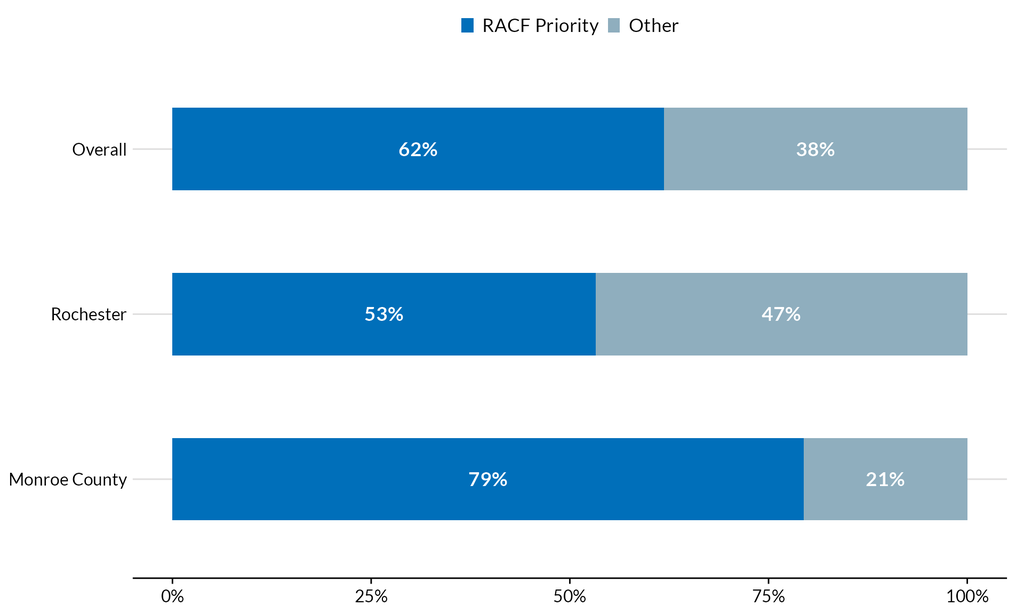

Source: Urban Institute calculations of data from [City of Rochester ARPA Reporting Dashboard](https://app.powerbi.com/view?r=eyJrIjoiNTg3NGZjNTYtYWI3NC00NTc3LWI1YTktZWJmMzY2NjBjNTBiIiwidCI6ImJlMjdkYTJlLTk0YjQtNDFkYS05NDdkLWY2MDJkNjBlODA3YyJ9) and [Monroe County Recovery Plan 2023 Annual Report](https://www.monroecounty.gov/files/planning/arpa/July_2023_ARPA_Report_V3_8-22-23_With_Attachments.pdf)

The figure below shows how SLFRF funding is divided among the priority topics and includes only the funds allocated to programs that align with one of RACF’s priority areas. The majority of the aligned funds are for partnering against poverty, followed by advancing environmental justice. Less well funded through SLFRF are preserving historical assets, promoting successful aging, and supporting arts and culture.

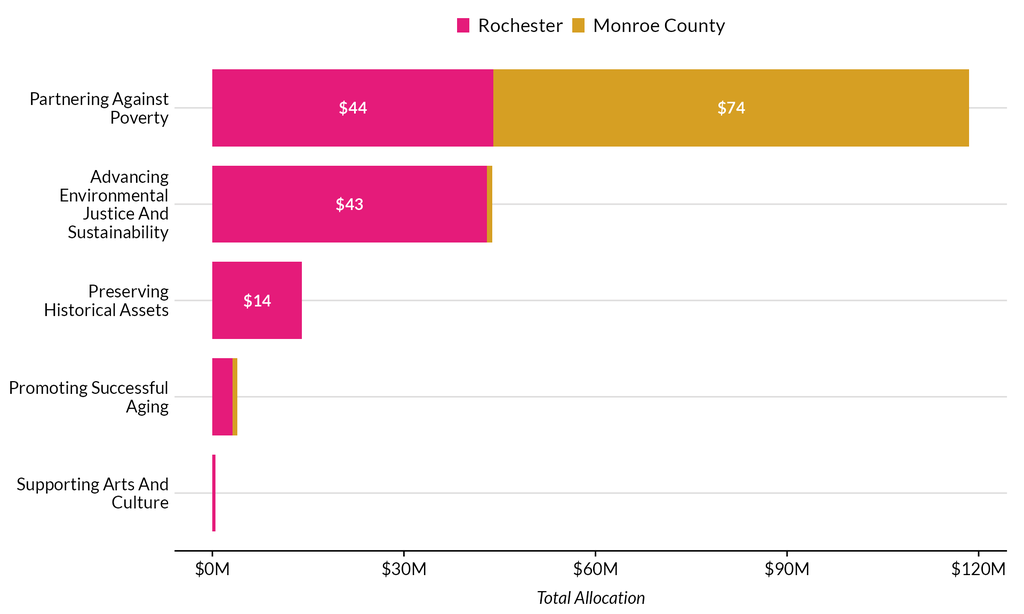

Source: Urban Institute calculations of data from [City of Rochester ARPA Reporting Dashboard](https://app.powerbi.com/view?r=eyJrIjoiNTg3NGZjNTYtYWI3NC00NTc3LWI1YTktZWJmMzY2NjBjNTBiIiwidCI6ImJlMjdkYTJlLTk0YjQtNDFkYS05NDdkLWY2MDJkNjBlODA3YyJ9) and [Monroe County Recovery Plan 2023 Annual Report](https://www.monroecounty.gov/files/planning/arpa/July_2023_ARPA_Report_V3_8-22-23_With_Attachments.pdf)

*How is Monroe County using federal funds to support local initiatives?*

[figure not shown]

Monroe County used 67% of their SLFRF funds to competitively fund community organizations and County departments that align with six focus areas: public safety, public health and wellness, economic recovery, workforce development, infrastructure improvements, and sustainability. One of the groups that received this funding is [Rochester ENergy Efficiency and Weatherization](https://www.racf.org/collaborations/rochester-energy-efficiency-and-weatherization/) (RENEW), a collective impact initiative in Rochester that helps income-qualified homeowners make their homes more energy-efficient, healthier, and safer from environmental hazards. RENEW [received $850,000 of SLFRF funds](https://www.monroecounty.gov/files/planning/arpa/July_2023_ARPA_Report_V3_8-22-23_With_Attachments%20-%20OLIVET%20UPDATED.pdf) from Monroe County to fund its grants for repairs or replacements in community members’ homes, including work on insulation, furnaces, hot water heaters, and emergency health and safety repairs of sewer lines and electrical panels. Using these funds, RENEW will assist at least 200 income-qualified homeowners and up to 800 residents living in those homes to complete projects that promote energy-efficiency, health, and/or safety goals. County funding also helped RENEW unlock $1 million in matching funds that interviewees noted the organization would not have been able to receive without the support of their work through SLFRF funds. [Listen](https://www.wxxinews.org/show/connections/2023-10-04/how-to-make-energy-efficiency-projects-more-accessible-to-all-homeowners) to an episode of WXXI’s Connections to hear about RENEW’s impact in the community.

> We’re hearing about the physical and mental health impacts, particularly the benefit to mental health from being able to have a home that is safe and healthy, and that you’re not worried about the leak in the basement or the fact that your utility bill is too difficult to pay.

> - Elizabeth McDade, RENEW Director

## Which neighborhoods are the funds allocated to?

The map below shows how the City of Rochester’s SLFRF capital investments map onto original Federal redlining maps, as well as racial characteristics of neighborhoods. **Click on the tabs at the top to also see how SLFRF capital investments overlap with the percent of residents who are Black** [^2] **in a neighborhood and the percent of residents who are Hispanic/Latino** [^3] **in a neighborhood.**

[Redlining](https://www.npr.org/2017/05/03/526655831/a-forgotten-history-of-how-the-u-s-government-segregated-america) refers to the system that the Federal Housing Administration and the Home Owners’ Loan Corporation used to grade the profitability of neighborhoods in the late 1930s. The four categories were green (areas most desirable for lending purposes), blue (still desirable), yellow (declining), and red (the riskiest for mortgage support). These grades were largely based on the neighborhood’s racial, ethnic, socioeconomic, and religious composition. Generally, white, middle-class neighborhoods received FHA home loans, whereas many Black and Hispanic/Latino neighborhoods were deemed hazardous and declining in value and did not receive FHA insured mortgages or loans. These maps [had long lasting effects](https://www.econstor.eu/bitstream/10419/200568/1/1010730592.pdf) on racial segregation, homeownership, and house values in redlined neighborhoods.

The maps below give us a first approximation of how equitably investments are distributed. We encourage further exploration of how these investments align with the goals of community members and how much they benefit historically excluded residents.

**Redlining**

[interactive chart not shown]

**Percent Black**

[interactive chart not shown]

**Percent Hispanic/Latino**

[interactive chart not shown]

*How might Rochester invest more into equity and inclusion?*

Other places have also found ways to use federal funds to invest in the building blocks of an inclusive recovery and equitable economy. For instance, the City of Boston is using ARPA funds to transform publicly-owned land into green, mixed income communities. One project in Chinatown, shown below, will include 83 affordable rental units and 36 affordable homeownership units. The property is located in a walkable and bikeable neighborhood and will be energy efficient and follow the City of Boston’s Carbon Free, Climate Resilient, and Healthy Community goals. It was developed after extensive community engagement with nearby neighbors. To read more about this and other investments into the building blocks of an inclusive recovery and equitable economy, see this [research summary](https://www.urban.org/research/publication/building-blocks-equitable-local-economies) from the Urban Institute that highlights one example from each building block.

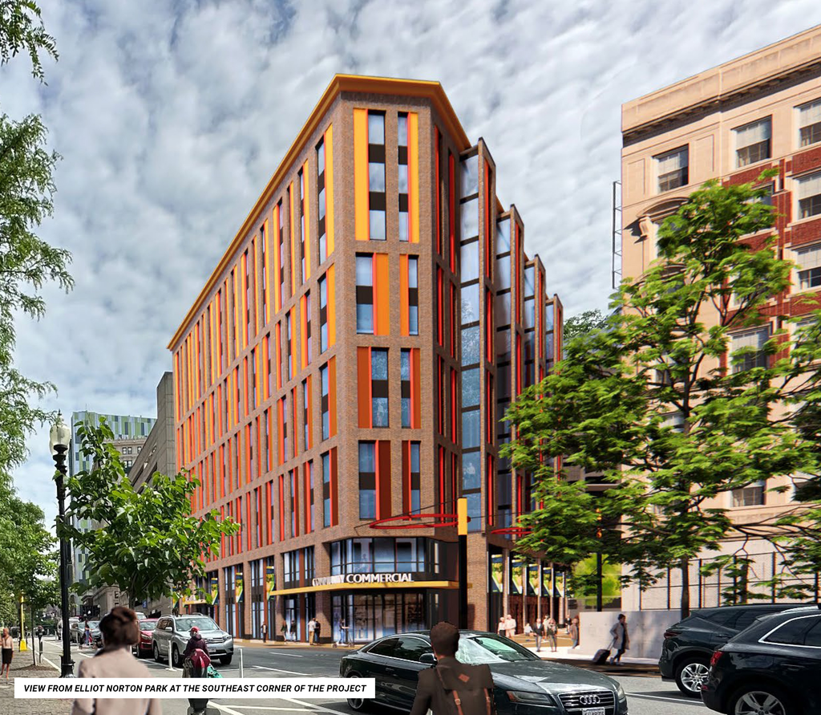

## Explore All Programs Funded

The table below shows all programs that the City of Rochester and Monroe County have allocated SLFRF funds to, as well as their building block, policy area, policy subtopic, and RACF priority area category. The default display on the table shows the programs in order from largest to smallest allocation. You can use the arrows next to each column title to sort the table by that column, and you can use the search bars under each column or the overall search bar to search the table.

**Data current as of**: 05/01/24

| Program | Geography | Allocated | Building Block | Policy Area | Subtopic | RACF Priority | Description | Agency |
| --- | --- | --- | --- | --- | --- | --- | --- | --- |
| Lead Service Replacement | Rochester | 36996975 | Reinvest in disinvested communities | Infrastructure | Water | Advancing Environmental Justice And Sustainability | Replacement of a portion of the city's lead, lead-lined and galvanized water services to remove any possible sources of lead contamination and complete associated street work. | Environmental Services |
| Workforce Development Services and Expansion | Rochester | 16415340 | Connect residents to jobs and economic opportunities | Community and Economic Development | Workforce Development | Partnering Against Poverty | Funding will be utilized to provide transformative workforce development experiences for adults and youth. Adult services include paid job training in multiple fields, job placement services, financia… | Recreation and Human Services |
| Buy the Block - Greenlining for a Better Rochester | Rochester | 13129162 | Create opportunities for low-wealth households to build wealth | Housing | Homeownership Supports | Partnering Against Poverty | New construction of homes for income-eligible, first-time homeowners on vacant lots in Rochester's fomer 'redlined' neighborhoods. | Neighborhood and Business Development |
| Parking Fund Revenue Replacement | Rochester | 11876500 | NA | Operations | Revenue Replacement | NA | Replacement of lost government revenues due to the pandemic. Funds will be utilized to support continuation of government services. | Finance |
| General Fund Revenue Replacement | Rochester | 11123500 | NA | Operations | Revenue Replacement | NA | Replacement of lost government revenues due to the pandemic. Funds will be utilized to support continuation of government services. | Varies |
| Transformational Community Care Coordination (TC3) | Monroe County | 11000000 | Connect residents to jobs and economic opportunities | Community and Economic Development | Workforce Development | Partnering Against Poverty | A workforce development program that would pay SNFs and HHCAs for the successful recruitment and training of certified nursing assistants (CNAs), home health aides (HHAs), licensed practical nurses (L… | FLPPS |
| Central Library - Rundel Building Exterior Improvements | Rochester | 8700000 | NA | Infrastructure | Libraries | Preserving Historical Assets | Repair, restoration and reconstruction of exterior parapets, limestone and brick masonry, historic windows, and structural framing systems for the east, south and north facades, and repairs to the adj… | Environmental Services |
| Roofing Rehabilitation Program | Rochester | 7702200 | Stabilize housing and expand affordable housing | Housing | Blight Mitigation | Partnering Against Poverty | Expansion of the City's high demand roofing assistance program. Funds may cover replacement of roofs, skylights, roof drains, gutters and roofign masonry structure/decking, and parapet reconstruction … | Neighborhood and Business Development |
| Neighborhood Collaborative Project (NCP) | Monroe County | 7160849 | Reinvest in disinvested communities | Social Services | Increasing Services in Underserved Neighborhoods | Partnering Against Poverty | Wraparound services and neighborhood outreach via collaboration between well-known community organizations in the crescent. | Community Resource Collaborative on Behalf of the Neighborhood Collaborative Project |
| Lead Service Replacement - Homeowner Grant Program | Rochester | 6000000 | Reinvest in disinvested communities | Housing | Blight Mitigation | Advancing Environmental Justice And Sustainability | The funds provided will assist residentail property owners in replacing lead service lines in an effort to reduce the amount of lead in drinking water. | Neighborhood and Business Development |

[output cut: 84 more lines]

## About the Dashboard

This dashboard was created by the Urban Institute in partnership with and support from [ACT Rochester](https://www.actrochester.org/) and [Rochester Area Community Foundation (RACF)](https://www.racf.org/) to visualize Monroe County and the City of Rochester’s SLFRF allocations by the five building blocks of an inclusive recovery and equitable economy, policy category, and RACF’s investment priorities. By tracking recovery funding allocations, this dashboard allows us to monitor public allocations by the categories most critical in supporting an inclusive recovery from the COVID-19 pandemic and an equitable economy.

For more information about the dashboard, please contact Meg Norris (ACT Rochester) or Christina Stacy (Urban Institute).

The code used to create this dashboard was written by Manuel Alcalá Kovalski and can be found on [GitHub](https://github.com/UI-Research/rochester-dashboard).

## Footnotes

[^1]: Simply allocating funds toward topics that could increase equity and inclusion does not guarantee that they do so. Future research efforts should closely monitor outcomes and impacts from the recovery dollar investments to ensure that they close equity gaps exacerbated by the pandemic and address the root causes of inequities.
[^2]: We use the term “Black” in this map to refer to the data collected by the American Community Survey under the category “Black or African American”. We recognize that this may not be the preferred identifier for all, and we remain committed to employing inclusive language whenever possible.
[^3]: We use the term “Hispanic/Latino” in this map because this is the term used in the data collected by the American Community Survey. We recognize that this may not be the preferred identifier for all, and we remain committed to employing inclusive language whenever possible.